# IE582 Homework 2

Burcu Çeştan - 2023702012

2024-12-15

# Introduction

This report analyzes match data, calculates implied probabilities, and generates insights by predicting football match outcomes using decision tree models and identifying market inefficiencies through comparisons between predicted probabilities and bookmaker-implied probabilities.

### Preprocessing Step

```r
# Load necessary libraries

library(readr)
library(dplyr)
library(ggplot2)
```

```r
# Load the data set
data <- read.csv("/Users/burcucestan/Desktop/HW2/match_data", header=TRUE)

# Display the first few rows of data
#cat("First few rows of the data:\n")
#head(data)

#cat("\nStructure of the data:\n")
#str(data)
```

```r
# Filtering the data
# Remove rows where "suspended" or "stopped" is TRUE
filtered_data <- data[data$suspended == "False" & data$stopped == "False", ]

# Retain 'result' and 'halftime' columns for further steps
results <- filtered_data$result
halftime <- filtered_data$halftime

# Calculate the percentage of missing values for each column
missing_percentage <- colSums(is.na(filtered_data)) / nrow(filtered_data) * 100

# Remove columns with more than 70% missing data
columns_to_remove <- names(missing_percentage[missing_percentage > 70])
filtered_data <- filtered_data[, !(names(filtered_data) %in% columns_to_remove)]

# Fill missing values in columns with less than 10% missing data
columns_to_impute <- names(missing_percentage[missing_percentage <= 10])
for (col in columns_to_impute) {
  if (is.numeric(filtered_data[[col]])) {
    filtered_data[[col]][is.na(filtered_data[[col]])] <- mean(filtered_data[[col]], na.rm = TRUE)
  }
}

# Re-add 'result' and 'halftime' columns to filtered data
filtered_data <- filtered_data %>%
  mutate(result = results, halftime = halftime)

# Check the dimensions of the filtered dataset
cat("\nDimensions of the filtered dataset:\n")
```

```
##
## Dimensions of the filtered dataset:
```

```r
dim(filtered_data)
```

```
## [1] 56127   102
```

### Data Filtering and Missing Data Handling

In the preprocessing step, we focused on both filtering and handling missing data to prepare the dataset for analysis.

#### Filtering:

Rows where the suspended or stopped columns were TRUE were removed as they indicate unreliable or incomplete data points. This reduced the data set to relevant and actionable records.

#### Missing Data Analysis:

We identified columns with missing values and categorized them based on the proportion of missing data: Columns with more than 70% missing values (e.g., “Free Kicks - home”) were removed due to their limited contribution to the analysis. For columns with less than 10% missing values, the gaps were filled using the mean value of the respective column to retain their predictive power.

The variables Free.Kicks.away, Free.Kicks.home, Injuries.away, and Injuries.home were removed because they contained over 70% missing values. Such high levels of missing data reduce their reliability and usefulness in the analysis, so they were excluded to maintain data quality.

#### Verification:

After filtering and imputation, we confirmed that the dataset was clean and ready for further statistical analysis. By addressing both filtering and missing data issues, we ensured the data set’s integrity and reliability, enabling accurate analysis in subsequent steps.

## TASK 1

```r
# Create a new data frame 'odds_data' to isolate odds columns and other relevant columns
odds_data <- filtered_data %>% select(fixture_id, X1, X2, X, result, halftime, minute)

# Convert odds columns (X1, X2, X) to numeric data type
odds_data <- odds_data %>% mutate(across(c(X1, X2, X), as.numeric))

# Calculate implied probabilities based on the odds columns
implied_probs <- odds_data %>%
  mutate(
    `Pr{Home Win}` = 1 / X1,    # Implied probability for Home Win
    `Pr{Away Win}` = 1 / X2,    # Implied probability for Away Win
    `Pr{Tie}` = 1 / X           # Implied probability for Tie
  ) %>%
  select(`Pr{Home Win}`, `Pr{Away Win}`, `Pr{Tie}`, result, halftime, fixture_id, minute)  # Select relevant columns for the output

# Display the first few rows of the resulting implied probabilities table
cat("Implied probabilities with result and halftime:\n")
```

```
## Implied probabilities with result and halftime:
```

```r
head(implied_probs)
```

```
##    Pr{Home Win} Pr{Away Win}   Pr{Tie} result halftime fixture_id minute
## 1     0.8196721   0.10000000 0.1538462      1 1st-half   19172016      9
## 2     0.8333333   0.07692308 0.1666667      1 1st-half   19172016     25
## 3     0.8333333   0.07692308 0.1666667      1 1st-half   19172016     26
## 4     0.8333333   0.07692308 0.1666667      1 1st-half   19172016     27
## 9     0.8333333   0.06666667 0.1666667      1 1st-half   19172016     32
## 10    0.8196721   0.07692308 0.1818182      1 1st-half   19172016     33
```

```r
#Calculate the normalization factor
implied_probs <- implied_probs %>%
  mutate(normalization_factor = `Pr{Home Win}` + `Pr{Away Win}` + `Pr{Tie}`)

#Normalize probabilities
normalized_probs <- implied_probs %>%
  mutate(
    `Pr{Home Win}` = `Pr{Home Win}` / normalization_factor,  # Normalize Home Win probability
    `Pr{Away Win}` = `Pr{Away Win}` / normalization_factor,  # Normalize Away Win probability
    `Pr{Tie}` = `Pr{Tie}` / normalization_factor             # Normalize Tie probability
  ) %>%
  select(-normalization_factor)  # Remove the normalization factor column

# Display the first few rows of the normalized probabilities table
cat("\nNormalized probabilities:\n")
```

```
##
## Normalized probabilities:
```

```r
head(normalized_probs)
```

```
##    Pr{Home Win} Pr{Away Win}   Pr{Tie} result halftime fixture_id minute
## 1     0.7635381   0.09315165 0.1433102      1 1st-half   19172016      9
## 2     0.7738095   0.07142857 0.1547619      1 1st-half   19172016     25
## 3     0.7738095   0.07142857 0.1547619      1 1st-half   19172016     26
## 4     0.7738095   0.07142857 0.1547619      1 1st-half   19172016     27
## 9     0.7812500   0.06250000 0.1562500      1 1st-half   19172016     32
## 10    0.7600723   0.07132986 0.1685979      1 1st-half   19172016     33
```

Construct the plots for each half first with not normalized probabilities:

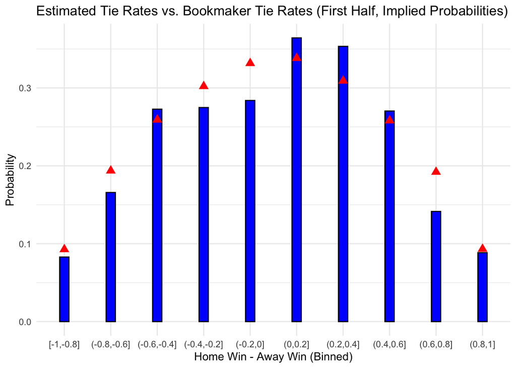

```r
# Define the bins with an interval of 0.2
bins <- seq(-1, 1, by = 0.2)  # Define bins from -1 to 1 with a step of 0.2

# Calculate the difference between Home Win and Away Win probabilities
implied_probs <- implied_probs %>%
  mutate(Difference = `Pr{Home Win}` - `Pr{Away Win}`)

# Assign each row to a bin based on the calculated difference
implied_probs <- implied_probs %>%
  mutate(Bin = cut(Difference, breaks = bins, include.lowest = TRUE))

# Filter data for the first half
first_half_data <- implied_probs %>%
  filter(halftime == "1st-half")

# Calculate the total number of games in each bin
bin_totals <- first_half_data %>%
  group_by(Bin) %>%
  summarize(TotalGames = n())

# Calculate the number of ties (draws) in each bin
bin_ties <- first_half_data %>%
  filter(result == "X") %>%
  group_by(Bin) %>%
  summarize(TieGames = n())

# Calculate the estimated tie probabilities for each bin
tie_probabilities <- bin_totals %>%
  left_join(bin_ties, by = "Bin") %>%
  mutate(
    TieGames = ifelse(is.na(TieGames), 0, TieGames),  # Replace NA values with 0
    EstimatedTieRate = TieGames / TotalGames
  )

# Calculate the average bookmaker tie probabilities for each bin
bookmaker_draws <- first_half_data %>%
  group_by(Bin) %>%
  summarize(BookmakerTieRate = mean(`Pr{Tie}`, na.rm = TRUE))

# Combine estimated and bookmaker probabilities into one dataset
visualization_data <- tie_probabilities %>%
  left_join(bookmaker_draws, by = "Bin")

# Visualize the results
library(ggplot2)

ggplot(visualization_data, aes(x = Bin)) +
  geom_bar(
    aes(y = EstimatedTieRate),
    stat = "identity",
    width = 0.2,
    fill = "blue",
    color = "black"
  ) +
  geom_point(
    aes(
      x = as.numeric(Bin),
      y = BookmakerTieRate
    ),
    color = "red",
    size = 3,    # Marker size
    shape = 17   # Triangle marker for bookmark style
  ) +
  labs(
    title = "Estimated Tie Rates vs. Bookmaker Tie Rates (First Half, Implied Probabilities)",
    x = "Home Win - Away Win (Binned)",
    y = "Probability"
  ) +
  theme_minimal()
```

The plot for the first half highlights a strong correlation between the evenly distributed probabilities of home and away wins (bins closer to 0) and the likelihood of a tie. In these central bins, both the estimated tie rates (blue bars) and bookmaker tie rates (red triangular markers) reach their highest values, indicating a higher chance of matches ending in draws when neither team has a distinct advantage. However, some deviations are noticeable in bins like (-0.6, -0.4) and (0.4, 0.6), where the estimated tie rates exceed the bookmaker predictions. This suggests a potential underestimation by bookmakers for these scenarios. The outer bins, such as [-1, -0.8] and (0.8, 1], show the lowest probabilities for ties, which aligns with the expectation that strong disparities between home and away win probabilities reduce the likelihood of a draw. The use of red triangular markers effectively emphasizes the bookmaker predictions, making the deviations in certain bins more visually apparent.

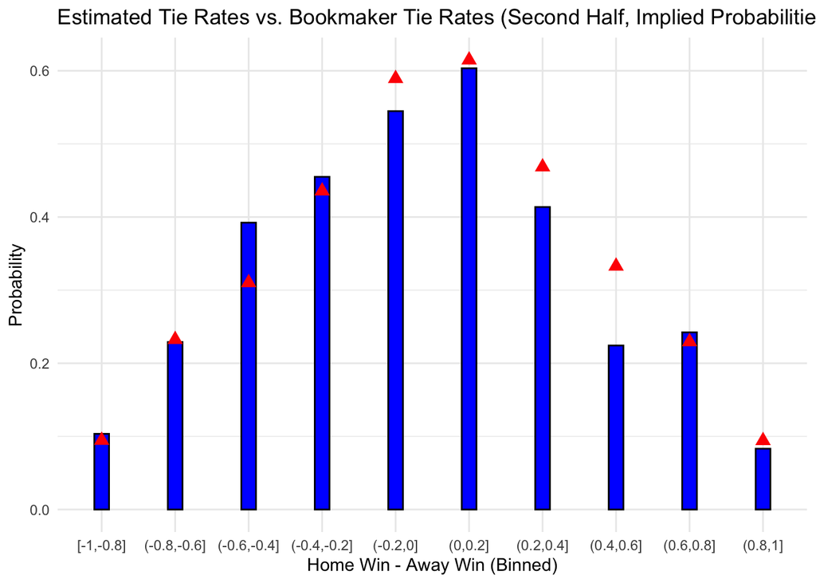

```r
# Define the bins with an interval of 0.2
bins <- seq(-1, 1, by = 0.2)  # Define bins from -1 to 1 with a step of 0.2

# Calculate the difference between Home Win and Away Win probabilities
implied_probs <- implied_probs %>%
  mutate(Difference = `Pr{Home Win}` - `Pr{Away Win}`)

# Assign each row to a bin based on the calculated difference
implied_probs <- implied_probs %>%
  mutate(Bin = cut(Difference, breaks = bins, include.lowest = TRUE))

# Filter data for the second half
second_half_data <- implied_probs %>%
  filter(halftime == "2nd-half")

# Calculate the total number of games in each bin
bin_totals_second_half <- second_half_data %>%
  group_by(Bin) %>%
  summarize(TotalGames = n())

# Calculate the number of ties (draws) in each bin
bin_ties_second_half <- second_half_data %>%
  filter(result == "X") %>%
  group_by(Bin) %>%
  summarize(TieGames = n())

# Calculate the estimated tie probabilities for each bin
tie_probabilities_second_half <- bin_totals_second_half %>%
  left_join(bin_ties_second_half, by = "Bin") %>%
  mutate(
    TieGames = ifelse(is.na(TieGames), 0, TieGames),  # Replace NA values with 0
    EstimatedTieRate = TieGames / TotalGames
  )

# Calculate the average bookmaker tie probabilities for each bin
bookmaker_draws_second_half <- second_half_data %>%
  group_by(Bin) %>%
  summarize(BookmakerTieRate = mean(`Pr{Tie}`, na.rm = TRUE))

# Combine estimated and bookmaker probabilities into one dataset
visualization_data_second_half <- tie_probabilities_second_half %>%
  left_join(bookmaker_draws_second_half, by = "Bin")

# Visualize the results with red triangular markers
library(ggplot2)

ggplot(visualization_data_second_half, aes(x = Bin)) +
  geom_bar(
    aes(y = EstimatedTieRate),
    stat = "identity",
    width = 0.2,
    fill = "blue",  # Use blue for the bars
    color = "black"
  ) +
  geom_point(
    aes(x = as.numeric(Bin), y = BookmakerTieRate),
    color = "red",
    shape = 17,  # Use a triangular shape
    size = 3
  ) +
  labs(
    title = "Estimated Tie Rates vs. Bookmaker Tie Rates (Second Half, Implied Probabilities)",
    x = "Home Win - Away Win (Binned)",
    y = "Probability"
  ) +
  theme_minimal()
```

The outer bins, such as [-1, -0.8] and (0.8, 1], retain the lowest tie probabilities, aligning with the expected outcome that games with a strong home or away advantage are less likely to end in a draw. Notably, in the second half, tie probabilities appear slightly elevated overall, suggesting that late-game factors, such as increased defensive tactics or player fatigue, might influence match outcomes. This dynamic underscores the potential for the second half to shift probabilities in favor of draws in balanced scenarios.

Then do the same with normalized probabilities:

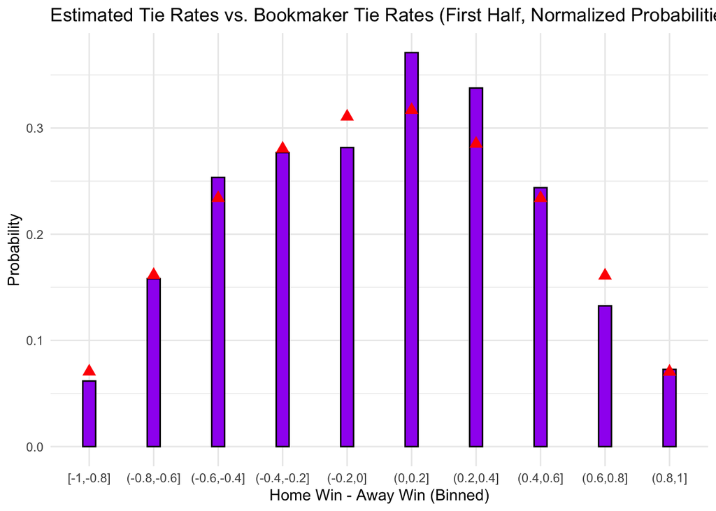

```r
# Define the bins with an interval of 0.2
bins <- seq(-1, 1, by = 0.2)  # Define bins from -1 to 1 with a step of 0.2

# Calculate the difference between Home Win and Away Win probabilities
normalized_probs <- normalized_probs %>%
  mutate(Difference = `Pr{Home Win}` - `Pr{Away Win}`)

# Assign each row to a bin based on the calculated difference
normalized_probs <- normalized_probs %>%
  mutate(Bin = cut(Difference, breaks = bins, include.lowest = TRUE))

# Filter data for the first half
first_half_data <- normalized_probs %>%
  filter(halftime == "1st-half")

# Calculate the total number of games in each bin
bin_totals <- first_half_data %>%
  group_by(Bin) %>%
  summarize(TotalGames = n())

# Calculate the number of ties (draws) in each bin
bin_ties <- first_half_data %>%
  filter(result == "X") %>%
  group_by(Bin) %>%
  summarize(TieGames = n())

# Calculate the estimated tie probabilities for each bin
tie_probabilities <- bin_totals %>%
  left_join(bin_ties, by = "Bin") %>%
  mutate(
    TieGames = ifelse(is.na(TieGames), 0, TieGames),  # Replace NA values with 0
    EstimatedTieRate = TieGames / TotalGames
  )

# Calculate the average bookmaker tie probabilities for each bin
bookmaker_draws <- first_half_data %>%
  group_by(Bin) %>%
  summarize(BookmakerTieRate = mean(`Pr{Tie}`, na.rm = TRUE))

# Combine estimated and bookmaker probabilities into one dataset
visualization_data <- tie_probabilities %>%
  left_join(bookmaker_draws, by = "Bin")

# Visualize the results
library(ggplot2)

ggplot(visualization_data, aes(x = Bin)) +
  geom_bar(
    aes(y = EstimatedTieRate),
    stat = "identity",
    width = 0.2,
    fill = "purple",
    color = "black"
  ) +
  geom_point(
    aes(
      x = as.numeric(Bin),
      y = BookmakerTieRate
    ),
    color = "red",
    size = 3,
    shape = 17  # Triangle marker
  ) +
  labs(
    title = "Estimated Tie Rates vs. Bookmaker Tie Rates (First Half, Normalized Probabilities)",
    x = "Home Win - Away Win (Binned)",
    y = "Probability"
  ) +
  theme_minimal()
```

There is a clear trend that matches with evenly distributed probabilities between home and away wins (bins closer to 0) have a higher likelihood of resulting in a tie, as indicated by both the estimated tie rates (purple bars) and the bookmaker tie rates (red triangular markers). However, deviations can be observed, particularly in bins such as (-0.6, -0.4) and (0.4, 0.6), where the estimated tie rates are notably higher than the bookmaker predictions.

This discrepancy suggests potential underestimations by bookmakers in these specific bins. In contrast, the outer bins (e.g., [-1, -0.8] and (0.8, 1]) exhibit the lowest tie rates, which aligns with the intuition that matches with strong probability disparities are less likely to end in ties. These patterns highlight areas where bookmaker predictions might benefit from adjustments to better capture the dynamics of evenly matched games.

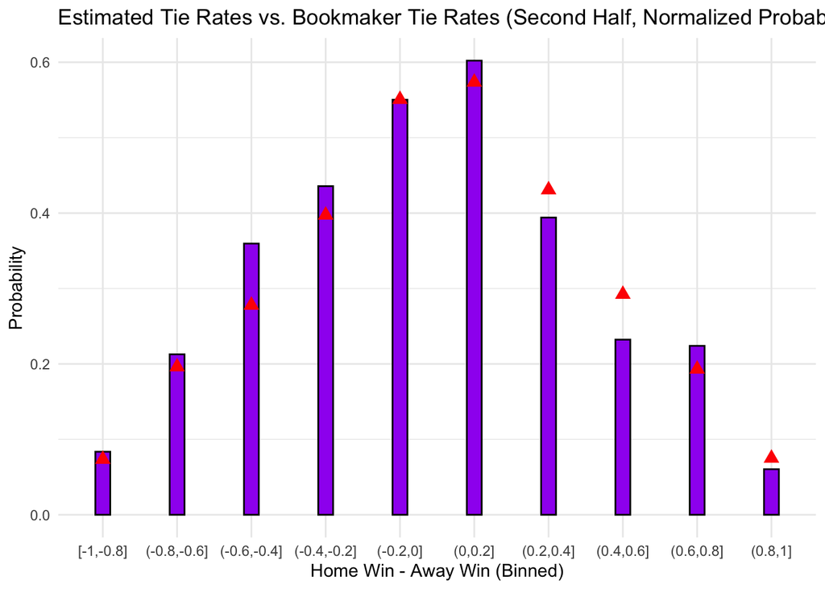

```r
# Define the bins with an interval of 0.2
bins <- seq(-1, 1, by = 0.2)  # Define bins from -1 to 1 with a step of 0.2

# Calculate the difference between Home Win and Away Win probabilities
normalized_probs <- normalized_probs %>%
  mutate(Difference = `Pr{Home Win}` - `Pr{Away Win}`)

# Assign each row to a bin based on the calculated difference
normalized_probs <- normalized_probs %>%
  mutate(Bin = cut(Difference, breaks = bins, include.lowest = TRUE))

# Filter data for the second half
second_half_data <- normalized_probs %>%
  filter(halftime == "2nd-half")

# Calculate the total number of games in each bin
bin_totals_second_half <- second_half_data %>%
  group_by(Bin) %>%
  summarize(TotalGames = n())

# Calculate the number of ties (draws) in each bin
bin_ties_second_half <- second_half_data %>%
  filter(result == "X") %>%
  group_by(Bin) %>%
  summarize(TieGames = n())

# Calculate the estimated tie probabilities for each bin
tie_probabilities_second_half <- bin_totals_second_half %>%
  left_join(bin_ties_second_half, by = "Bin") %>%
  mutate(
    TieGames = ifelse(is.na(TieGames), 0, TieGames),  # Replace NA values with 0
    EstimatedTieRate = TieGames / TotalGames
  )

# Calculate the average bookmaker tie probabilities for each bin
bookmaker_draws_second_half <- second_half_data %>%
  group_by(Bin) %>%
  summarize(BookmakerTieRate = mean(`Pr{Tie}`, na.rm = TRUE))

# Combine estimated and bookmaker probabilities into one dataset
visualization_data_second_half <- tie_probabilities_second_half %>%
  left_join(bookmaker_draws_second_half, by = "Bin")

# Visualize the results
library(ggplot2)

ggplot(visualization_data_second_half, aes(x = Bin)) +
  geom_bar(
    aes(y = EstimatedTieRate),
    stat = "identity",
    width = 0.2,
    fill = "purple",  # Use purple for the bars
    color = "black"
  ) +
  geom_point(
    aes(
      x = as.numeric(Bin),
      y = BookmakerTieRate
    ),
    color = "red",
    shape = 17,  # Shape 17 represents a triangle in ggplot2
    size = 3     # Adjust size for visibility
  ) +
  labs(
    title = "Estimated Tie Rates vs. Bookmaker Tie Rates (Second Half, Normalized Probabilities)",
    x = "Home Win - Away Win (Binned)",
    y = "Probability"
  ) +
  theme_minimal()
```

The outer bins, such as [-1, -0.8] and (0.8, 1], maintain their trend of lower tie probabilities, consistent with the intuition that matches with strong home or away advantages are less likely to end in ties.

Overall, the second half shows slightly higher estimated tie probabilities compared to the first half, potentially reflecting cautious strategies, defensive gameplay, or fatigue influencing outcomes. These dynamics highlight the importance of match context and team adjustments in shaping probabilities during the second half.

## TASK 2

##### Noise Data Cases:

##### 1. Goals Scored in the First 10 Minutes

- **Why Noise?**: The first 10 minutes of a match are often a period where teams are settling into the game. Goals scored during this time can disrupt the natural flow of the match and disproportionately affect the outcome.

##### 2. Goals Scored After the 85th Minute

- **Why Noise?**: Goals scored in the final minutes of a match are often the result of defensive errors, aggressive attacks, or time-wasting strategies. These do not reflect the overall dynamics of the game.

##### 3. Substitutions in the First 30 Minutes

- **Why Noise?**: Substitutions made in the first 30 minutes are typically due to injuries or tactical adjustments, which can significantly alter the course of the match and skew the implied probabilities.

##### 4. Penalty Awarded in the First 15 Minutes

- **Why Noise?**: A penalty in the first 15 minutes can significantly alter the match outcome by giving one team an early lead, which may not represent the actual competitiveness of the teams.

##### 5. Multiple Yellow Cards in the First 20 Minutes

- **Why Noise?**: Multiple yellow cards in the first 20 minutes often indicate aggressive play or referee bias, which can lead to early tactical shifts and disrupt the natural flow of the game.

```r
# Add a new column for the "actual minute" of the match
filtered_data <- filtered_data %>%
  mutate(
    actual_minute = ifelse(halftime == "1st-half", minute, minute + 45)
  )

# Case 1: Goals in the first 10 minutes
filtered_data <- filtered_data %>%
  mutate(
    Goal_in_first_10_mins = ifelse(
      actual_minute <= 10 & (`Goals...home` + `Goals...away`) >= 1,
      TRUE, FALSE
    )
  )

# Case 2: Goals after the 85th minute
filtered_data <- filtered_data %>%
  mutate(
    Goal_after_85_mins = ifelse(
      actual_minute > 85 & (`Goals...home` + `Goals...away`) >= 1,
      TRUE, FALSE
    )
  )

# Case 3: Substitutions in the first 30 minutes
filtered_data <- filtered_data %>%
  mutate(
    Substitutions_in_first_30_mins = ifelse(
      halftime == "1st-half" & actual_minute <= 30 &
      (`Substitutions...home` + `Substitutions...away`) >= 1,
      TRUE, FALSE
    )
  )

# Case 4: Penalty Awarded in the First 15 Minutes
filtered_data <- filtered_data %>%
  mutate(
    Penalty_in_first_15_mins = ifelse(
      halftime == "1st-half" & actual_minute <= 15 &
      (`Penalties...home` + `Penalties...away`) >= 1,
      TRUE, FALSE
    )
  )

# Case 5: Multiple Yellow Cards in the First 20 Minutes
filtered_data <- filtered_data %>%
  mutate(
    Multiple_yellow_cards_first_20_mins = ifelse(
      halftime == "1st-half" & actual_minute <= 20 &
      (`Yellowcards...home` + `Yellowcards...away`) > 1,
      TRUE, FALSE
    )
  )

# Calculate and print the number of matches fitting each case
cat("Number of matches with a goal before 10 minutes: ", sum(filtered_data$Goal_in_first_10_mins), "\n")
```

```
## Number of matches with a goal before 10 minutes:  667
```

```r
cat("Number of matches with a goal after 85 minutes: ", sum(filtered_data$Goal_after_85_mins), "\n")
```

```
## Number of matches with a goal after 85 minutes:  3836
```

```r
cat("Number of matches with substitutions in the first 30 minutes: ",
    sum(filtered_data$Substitutions_in_first_30_mins), "\n")
```

```
## Number of matches with substitutions in the first 30 minutes:  943
```

```r
cat("Number of matches with a penalty in the first 15 minutes: ",
    sum(filtered_data$Penalty_in_first_15_mins), "\n")
```

```
## Number of matches with a penalty in the first 15 minutes:  105
```

```r
cat("Number of matches with multiple yellow cards in the first 20 minutes: ",
    sum(filtered_data$Multiple_yellow_cards_first_20_mins), "\n")
```

```
## Number of matches with multiple yellow cards in the first 20 minutes:  242
```

```r
# Create a new dataset for cleaned data after removing noisy rows
cleaned_data <- filtered_data %>%
  filter(
    !(Goal_in_first_10_mins |
      Goal_after_85_mins |
      Substitutions_in_first_30_mins |
      Penalty_in_first_15_mins |
      Multiple_yellow_cards_first_20_mins)
  )

# Calculate and print the number of rows removed
original_row_count <- nrow(filtered_data)
removed_row_count <- original_row_count - nrow(cleaned_data)

cat("Number of rows removed as noisy data: ", removed_row_count, "\n")
```

```
## Number of rows removed as noisy data:  5618
```

```r
cat("Number of rows in the cleaned dataset: ", nrow(cleaned_data), "\n")
```

```
## Number of rows in the cleaned dataset:  50509
```

After removing the identified noisy data, we proceed to perform the third and fourth subtasks of Task 1 using the cleaned data set.

```r
# Create a new data frame 'cleaned_odds_data' to isolate odds columns and other relevant columns
cleaned_odds_data <- cleaned_data %>% select(X1, X2, X, result, halftime)

# Convert odds columns (X1, X2, X) to numeric data type
cleaned_odds_data <- cleaned_odds_data %>% mutate(across(c(X1, X2, X), as.numeric))

# Calculate implied probabilities based on the odds columns
cleaned_implied_probs <- cleaned_odds_data %>%
  mutate(
    `Pr{Home Win}` = 1 / X1,    # Implied probability for Home Win
    `Pr{Away Win}` = 1 / X2,    # Implied probability for Away Win
    `Pr{Tie}` = 1 / X           # Implied probability for Tie
  ) %>%
  select(`Pr{Home Win}`, `Pr{Away Win}`, `Pr{Tie}`, result, halftime)  # Select relevant columns for the output

# Display the first few rows of the resulting implied probabilities table
cat("Implied probabilities with result and halftime:\n")
```

```
## Implied probabilities with result and halftime:
```

```r
head(cleaned_implied_probs)
```

```
##   Pr{Home Win} Pr{Away Win}   Pr{Tie} result halftime
## 1    0.8196721   0.10000000 0.1538462      1 1st-half
## 2    0.8333333   0.07692308 0.1666667      1 1st-half
## 3    0.8333333   0.07692308 0.1666667      1 1st-half
## 4    0.8333333   0.07692308 0.1666667      1 1st-half
## 5    0.8333333   0.06666667 0.1666667      1 1st-half
## 6    0.8196721   0.07692308 0.1818182      1 1st-half
```

```r
# Calculate the normalization factor
cleaned_implied_probs <- cleaned_implied_probs %>%
  mutate(normalization_factor = `Pr{Home Win}` + `Pr{Away Win}` + `Pr{Tie}`)

# Normalize probabilities
cleaned_normalized_probs <- cleaned_implied_probs %>%
  mutate(
    `Pr{Home Win}` = `Pr{Home Win}` / normalization_factor,  # Normalize Home Win probability
    `Pr{Away Win}` = `Pr{Away Win}` / normalization_factor,  # Normalize Away Win probability
    `Pr{Tie}` = `Pr{Tie}` / normalization_factor             # Normalize Tie probability
  ) %>%
  select(-normalization_factor)  # Remove the normalization factor column

# Display the first few rows of the normalized probabilities table
cat("\nNormalized probabilities:\n")
```

```
##
## Normalized probabilities:
```

```r
head(cleaned_normalized_probs)
```

```
##   Pr{Home Win} Pr{Away Win}   Pr{Tie} result halftime
## 1    0.7635381   0.09315165 0.1433102      1 1st-half
## 2    0.7738095   0.07142857 0.1547619      1 1st-half
## 3    0.7738095   0.07142857 0.1547619      1 1st-half
## 4    0.7738095   0.07142857 0.1547619      1 1st-half
## 5    0.7812500   0.06250000 0.1562500      1 1st-half
## 6    0.7600723   0.07132986 0.1685979      1 1st-half
```

```r
# Validate that all rows sum to 1
# Calculate row sums for normalized probabilities
row_sums <- rowSums(cleaned_normalized_probs %>% select(`Pr{Home Win}`, `Pr{Away Win}`, `Pr{Tie}`))

# Check if all rows sum to 1
cat("\nDo all rows sum to 1? ", all.equal(row_sums, rep(1, nrow(cleaned_normalized_probs))), "\n")
```

```
##
## Do all rows sum to 1?  TRUE
```

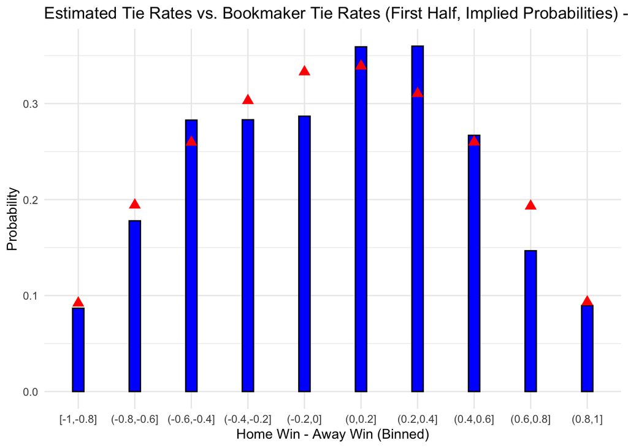

```r
# Define the bins with an interval of 0.2
bins <- seq(-1, 1, by = 0.2)  # Define bins from -1 to 1 with a step of 0.2

# Calculate the difference between Home Win and Away Win probabilities
cleaned_implied_probs <- cleaned_implied_probs %>%
  mutate(Difference = `Pr{Home Win}` - `Pr{Away Win}`)

# Assign each row to a bin based on the calculated difference
cleaned_implied_probs <- cleaned_implied_probs %>%
  mutate(Bin = cut(Difference, breaks = bins, include.lowest = TRUE))

# Filter data for the first half
first_half_data <- cleaned_implied_probs %>%
  filter(halftime == "1st-half")

# Calculate the total number of games in each bin
bin_totals <- first_half_data %>%
  group_by(Bin) %>%
  summarize(TotalGames = n())

# Calculate the number of ties (draws) in each bin
bin_ties <- first_half_data %>%
  filter(result == "X") %>%
  group_by(Bin) %>%
  summarize(TieGames = n())

# Calculate the estimated tie probabilities for each bin
tie_probabilities <- bin_totals %>%
  left_join(bin_ties, by = "Bin") %>%
  mutate(
    TieGames = ifelse(is.na(TieGames), 0, TieGames),  # Replace NA values with 0
    EstimatedTieRate = TieGames / TotalGames
  )

# Calculate the average bookmaker tie probabilities for each bin
bookmaker_draws <- first_half_data %>%
  group_by(Bin) %>%
  summarize(BookmakerTieRate = mean(`Pr{Tie}`, na.rm = TRUE))

# Combine estimated and bookmaker probabilities into one dataset
visualization_data <- tie_probabilities %>%
  left_join(bookmaker_draws, by = "Bin")

# Visualize the results
library(ggplot2)

ggplot(visualization_data, aes(x = Bin)) +
  geom_bar(
    aes(y = EstimatedTieRate),
    stat = "identity",
    width = 0.2,
    fill = "blue",
    color = "black"
  ) +
  geom_point(
    aes(
      x = as.numeric(Bin),
      y = BookmakerTieRate
    ),
    color = "red",
    size = 3,    # Marker size
    shape = 17   # Triangle marker for bookmark style
  ) +
  labs(
    title = "Estimated Tie Rates vs. Bookmaker Tie Rates (First Half, Implied Probabilities) - After Noise Removal",
    x = "Home Win - Away Win (Binned)",
    y = "Probability"
  ) +
  theme_minimal()
```

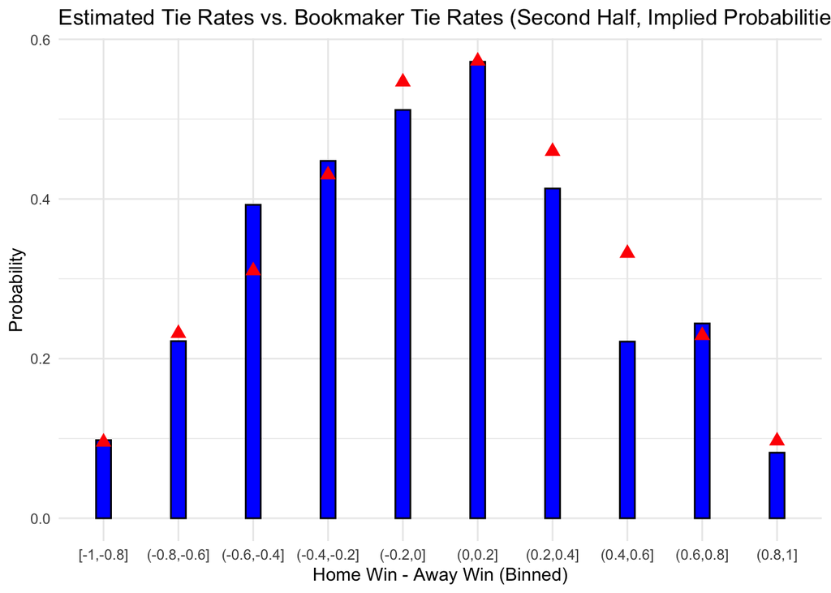

```r
# Define the bins with an interval of 0.2
bins <- seq(-1, 1, by = 0.2)  # Define bins from -1 to 1 with a step of 0.2

# Calculate the difference between Home Win and Away Win probabilities
cleaned_implied_probs <- cleaned_implied_probs %>%
  mutate(Difference = `Pr{Home Win}` - `Pr{Away Win}`)

# Assign each row to a bin based on the calculated difference
cleaned_implied_probs <- cleaned_implied_probs %>%
  mutate(Bin = cut(Difference, breaks = bins, include.lowest = TRUE))

# Filter data for the first half
second_half_data <- cleaned_implied_probs %>%
  filter(halftime == "2nd-half")

# Calculate the total number of games in each bin
bin_totals <- second_half_data %>%
  group_by(Bin) %>%
  summarize(TotalGames = n())

# Calculate the number of ties (draws) in each bin
bin_ties <- second_half_data %>%
  filter(result == "X") %>%
  group_by(Bin) %>%
  summarize(TieGames = n())

# Calculate the estimated tie probabilities for each bin
tie_probabilities <- bin_totals %>%
  left_join(bin_ties, by = "Bin") %>%
  mutate(
    TieGames = ifelse(is.na(TieGames), 0, TieGames),  # Replace NA values with 0
    EstimatedTieRate = TieGames / TotalGames
  )

# Calculate the average bookmaker tie probabilities for each bin
bookmaker_draws <- second_half_data %>%
  group_by(Bin) %>%
  summarize(BookmakerTieRate = mean(`Pr{Tie}`, na.rm = TRUE))

# Combine estimated and bookmaker probabilities into one dataset
visualization_data <- tie_probabilities %>%
  left_join(bookmaker_draws, by = "Bin")

# Visualize the results
library(ggplot2)

ggplot(visualization_data, aes(x = Bin)) +
  geom_bar(
    aes(y = EstimatedTieRate),
    stat = "identity",
    width = 0.2,
    fill = "blue",
    color = "black"
  ) +
  geom_point(
    aes(
      x = as.numeric(Bin),
      y = BookmakerTieRate
    ),
    color = "red",
    size = 3,    # Marker size
    shape = 17   # Triangle marker for bookmark style
  ) +
  labs(
    title = "Estimated Tie Rates vs. Bookmaker Tie Rates (Second Half, Implied Probabilities)-After Noise Removal",
    x = "Home Win - Away Win (Binned)",
    y = "Probability"
  ) +
  theme_minimal()
```

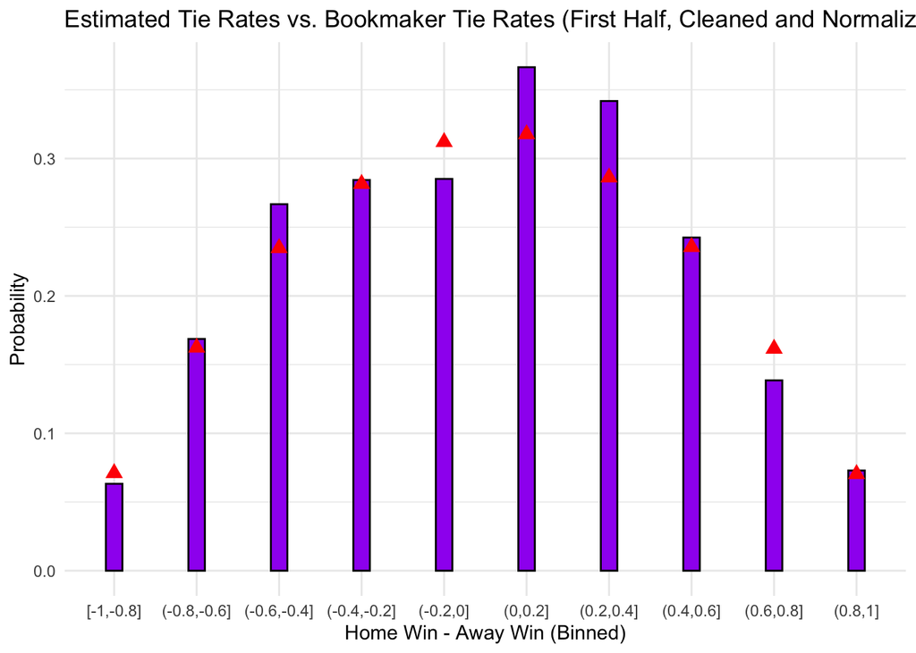

```r
# Define the bins with an interval of 0.2
bins <- seq(-1, 1, by = 0.2)  # Define bins from -1 to 1 with a step of 0.2

# Calculate the difference between Home Win and Away Win probabilities
cleaned_normalized_probs <- cleaned_normalized_probs %>%
  mutate(Difference = `Pr{Home Win}` - `Pr{Away Win}`)

# Assign each row to a bin based on the calculated difference
cleaned_normalized_probs <- cleaned_normalized_probs %>%
  mutate(Bin = cut(Difference, breaks = bins, include.lowest = TRUE))

# Filter data for the first half
first_half_data <- cleaned_normalized_probs %>%
  filter(halftime == "1st-half")

# Calculate the total number of games in each bin
bin_totals <- first_half_data %>%
  group_by(Bin) %>%
  summarize(TotalGames = n())

# Calculate the number of ties (draws) in each bin
bin_ties <- first_half_data %>%
  filter(result == "X") %>%
  group_by(Bin) %>%
  summarize(TieGames = n())

# Calculate the estimated tie probabilities for each bin
tie_probabilities <- bin_totals %>%
  left_join(bin_ties, by = "Bin") %>%
  mutate(
    TieGames = ifelse(is.na(TieGames), 0, TieGames),  # Replace NA values with 0
    EstimatedTieRate = TieGames / TotalGames
  )

# Calculate the average bookmaker tie probabilities for each bin
bookmaker_draws <- first_half_data %>%
  group_by(Bin) %>%
  summarize(BookmakerTieRate = mean(`Pr{Tie}`, na.rm = TRUE))

# Combine estimated and bookmaker probabilities into one dataset
visualization_data <- tie_probabilities %>%
  left_join(bookmaker_draws, by = "Bin")

# Visualize the results for the first half
library(ggplot2)

ggplot(visualization_data, aes(x = Bin)) +
  geom_bar(
    aes(y = EstimatedTieRate),
    stat = "identity",
    width = 0.2,
    fill = "purple",
    color = "black"
  ) +
  geom_point(
    aes(
      x = as.numeric(Bin),
      y = BookmakerTieRate
    ),
    color = "red",
    size = 3,    # Marker size
    shape = 17   # Triangle marker for bookmark style
  ) +
  labs(
    title = "Estimated Tie Rates vs. Bookmaker Tie Rates (First Half, Cleaned and Normalized Probabilities)",
    x = "Home Win - Away Win (Binned)",
    y = "Probability"
  ) +
  theme_minimal()
```

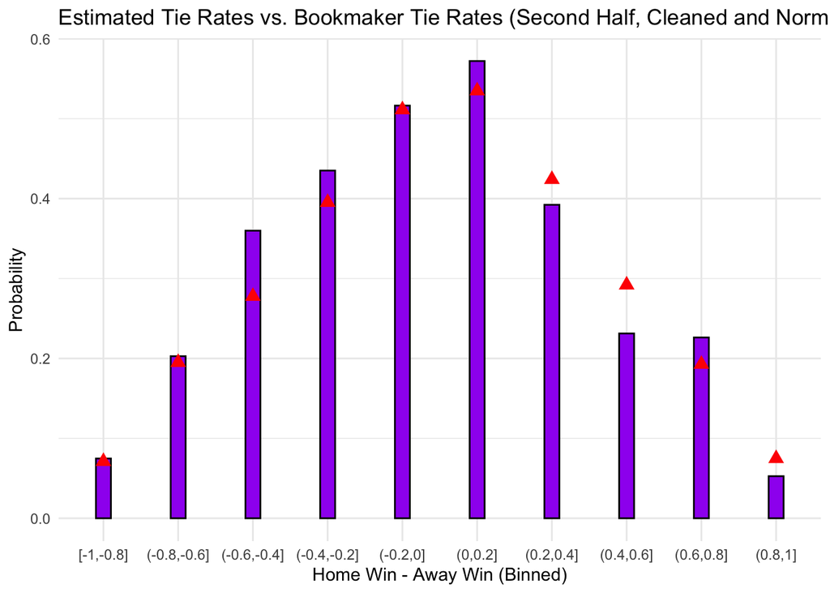

```r
# Define the bins with an interval of 0.2
bins <- seq(-1, 1, by = 0.2)  # Define bins from -1 to 1 with a step of 0.2

# Calculate the difference between Home Win and Away Win probabilities
cleaned_normalized_probs <- cleaned_normalized_probs %>%
  mutate(Difference = `Pr{Home Win}` - `Pr{Away Win}`)

# Assign each row to a bin based on the calculated difference
cleaned_normalized_probs <- cleaned_normalized_probs %>%
  mutate(Bin = cut(Difference, breaks = bins, include.lowest = TRUE))


second_half_data <- cleaned_normalized_probs %>%
  filter(halftime == "2nd-half")

# Calculate the total number of games in each bin
bin_totals <- second_half_data %>%
  group_by(Bin) %>%
  summarize(TotalGames = n())

# Calculate the number of ties (draws) in each bin
bin_ties <- second_half_data %>%
  filter(result == "X") %>%
  group_by(Bin) %>%
  summarize(TieGames = n())

# Calculate the estimated tie probabilities for each bin
tie_probabilities <- bin_totals %>%
  left_join(bin_ties, by = "Bin") %>%
  mutate(
    TieGames = ifelse(is.na(TieGames), 0, TieGames),  # Replace NA values with 0
    EstimatedTieRate = TieGames / TotalGames
  )

# Calculate the average bookmaker tie probabilities for each bin
bookmaker_draws <- second_half_data %>%
  group_by(Bin) %>%
  summarize(BookmakerTieRate = mean(`Pr{Tie}`, na.rm = TRUE))

# Combine estimated and bookmaker probabilities into one dataset
visualization_data <- tie_probabilities %>%
  left_join(bookmaker_draws, by = "Bin")


library(ggplot2)

ggplot(visualization_data, aes(x = Bin)) +
  geom_bar(
    aes(y = EstimatedTieRate),
    stat = "identity",
    width = 0.2,
    fill = "purple",
    color = "black"
  ) +
  geom_point(
    aes(
      x = as.numeric(Bin),
      y = BookmakerTieRate
    ),
    color = "red",
    size = 3,    # Marker size
    shape = 17   # Triangle marker for bookmark style
  ) +
  labs(
    title = "Estimated Tie Rates vs. Bookmaker Tie Rates (Second Half, Cleaned and Normalized Probabilities)",
    x = "Home Win - Away Win (Binned)",
    y = "Probability"
  ) +
  theme_minimal()
```

## TASK 3

In this step, the dataset was prepared for the decision tree model by creating a numeric target column to encode match outcomes (1 for home win, 2 for away win, 0 for draw). Irrelevant columns, such as penalty and assist stats (already captured in goals), bookmaker odds, and result columns, were removed to simplify the data and avoid redundancy. The cleaned dataset, prepared_data, is now streamlined and ready for further feature engineering.

```r
# Add the target column to the cleaned dataset
cleaned_data$target <- ifelse(cleaned_data$result == "1", 1,  # Home team wins
                       ifelse(cleaned_data$result == "2", 2,  # Away team wins
                         0))                                  # Tie

# Remove irrelevant columns from the cleaned dataset
columns_to_remove <- c("Penalties...home", "Penalties...away", "Assists...home", "Assists...away",
                      "current_time", "half_start_datetime", "match_start_datetime",
                       "latest_bookmaker_update", "suspended", "stopped", "name", "second", "ticking",
                       "result", "final_score", "X1", "X2", "X")

# Update the cleaned dataset by removing the specified columns
prepared_data <- cleaned_data[, !(names(cleaned_data) %in% columns_to_remove)]

prepared_data$halftime <- ifelse(prepared_data$halftime == "1st-half", 1,
                                 ifelse(prepared_data$halftime == "2nd-half", 2, NA))

# Display the first few rows of the updated dataset
#head(prepared_data)

# Convert the target column to factor with labels
prepared_data$target <- factor(prepared_data$target,
                               levels = c(0, 1, 2),
                               labels = c("Tie", "Home Win", "Away Win"))

# Verify the conversion
print(table(prepared_data$target))
```

```
##
##      Tie Home Win Away Win
##    13917    21734    14858
```

Here, several additional features were created and existing ones were transformed to better suit the decision tree model. These changes aim to enhance the interpretability and predictive power of the model:

```r
# Add "Combined_Goals" column (sum of home and away goals)
prepared_data$Combined_Goals <- prepared_data$Goals...home + prepared_data$Goals...away

# Add "Net_Goal_Difference" column (net difference between home and away goals)
prepared_data$Net_Goal_Difference <- prepared_data$Goals...home - prepared_data$Goals...away

# Add "Aggressive_Attack_Balance" column (difference between home and away dangerous attacks)
prepared_data$Aggressive_Attack_Balance <- prepared_data$Dangerous.Attacks...home - prepared_data$Dangerous.Attacks...away

# Add "Possession_Imbalance" column (difference between home and away ball possession percentages)
prepared_data$Possession_Imbalance <- prepared_data$Ball.Possession.....home - prepared_data$Ball.Possession.....away


# Add "Shot_Effort_Difference" column (difference between home and away goal attempts)
prepared_data$Shot_Effort_Difference <- prepared_data$Goal.Attempts...home - prepared_data$Goal.Attempts...away

# Add "Match_Minute_Tracker" column (cumulative match minute tracker)
prepared_data$Match_Minute_Tracker <- with(prepared_data, ifelse(halftime == "1st-half", minute, minute + 45))

# Optional Enhancements: Add new derived features for deeper analysis
# Add "Goal_Ratio" column (ratio of home goals to away goals, avoiding division by zero)
prepared_data$Goal_Ratio <- ifelse(prepared_data$Goals...away == 0,
                                   prepared_data$Goals...home,
                                   prepared_data$Goals...home / prepared_data$Goals...away)

# Add "Dangerous_Attacks_Ratio" column (ratio of home to away dangerous attacks)
prepared_data$Dangerous_Attacks_Ratio <- ifelse(prepared_data$Dangerous.Attacks...away == 0,
                                                prepared_data$Dangerous.Attacks...home,
                                                prepared_data$Dangerous.Attacks...home / prepared_data$Dangerous.Attacks...away)

# Add "Possession_Dominance_Flag" column (flag indicating significant possession advantage for one team)
prepared_data$Possession_Dominance_Flag <- ifelse(abs(prepared_data$Possession_Imbalance) > 20, 1, 0)


# Display the first few rows of the modified dataset
#head(prepared_data)
```

```r
# Display column names to ensure the dataset includes necessary features
#print(names(prepared_data))

# Show the first few rows to check data consistency
#print(head(prepared_data))

#Remove any rows with missing target values
prepared_data <- prepared_data[!is.na(prepared_data$target), ]
```

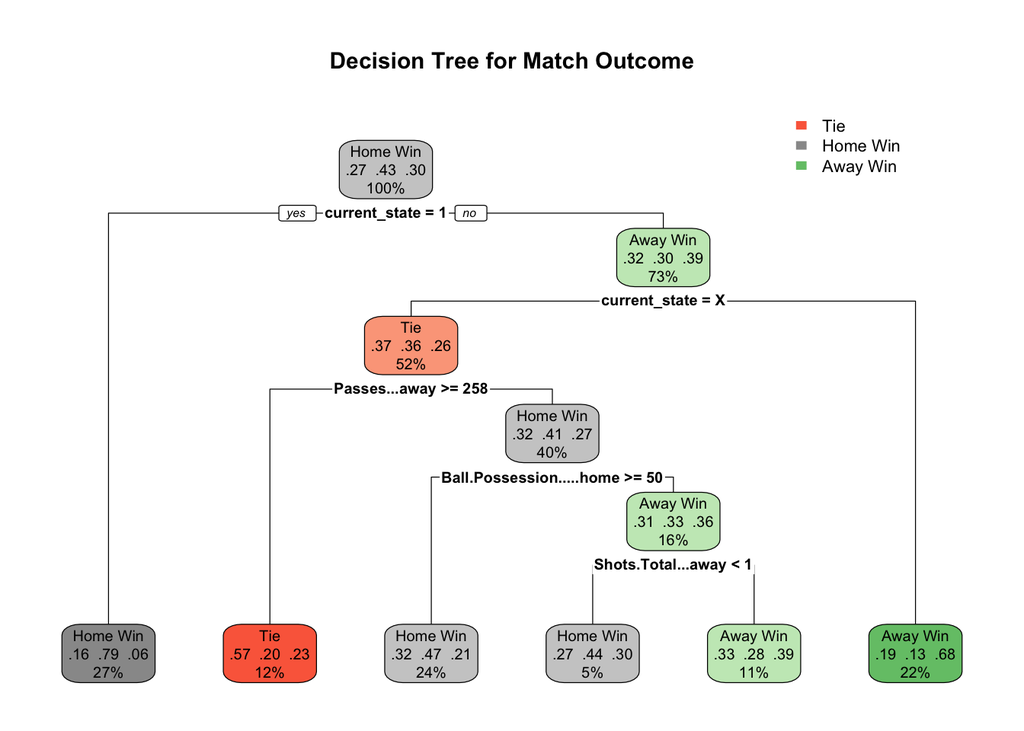

```r
# Load necessary libraries
library(rpart)
library(rpart.plot)

# Define the target variable and features
features <- prepared_data[, !(names(prepared_data) %in% c("target"))]
target <- prepared_data$target

# Combine into a single dataframe
model_data <- prepared_data[, c(names(features), "target")]

# Train-test split (70-30)
set.seed(123)  # For reproducibility
train_indices <- sample(1:nrow(model_data), 0.7 * nrow(model_data))
train_data <- model_data[train_indices, ]
test_data <- model_data[-train_indices, ]

# Train a decision tree
decision_tree <- rpart(target ~ .,
                       data = train_data,
                       method = "class",
                       control = rpart.control(maxdepth = 5))

# Visualize the decision tree
rpart.plot(decision_tree, main = "Decision Tree for Match Outcome")
```

```r
# Predict outcomes for the test data
predictions <- predict(decision_tree, newdata = test_data, type = "class")

# Generate a confusion matrix
confusion_matrix <- table(test_data$target, predictions)

# Print the confusion matrix
print("Confusion Matrix:")
```

```
## [1] "Confusion Matrix:"
```

```r
print(confusion_matrix)
```

```
##           predictions
##             Tie Home Win Away Win
##   Tie       986     2041     1184
##   Home Win  329     5367      906
##   Away Win  376     1119     2845
```

```r
# Calculate model accuracy
accuracy <- sum(diag(confusion_matrix)) / sum(confusion_matrix)
print(paste("Model Accuracy:", round(accuracy, 3)))
```

```
## [1] "Model Accuracy: 0.607"
```

```r
library(caret)
# Generate detailed performance metrics
confusion_details <- confusionMatrix(predictions, as.factor(test_data$target))
print(confusion_details)
```

```
## Confusion Matrix and Statistics
##
##           Reference
## Prediction  Tie Home Win Away Win
##   Tie       986      329      376
##   Home Win 2041     5367     1119
##   Away Win 1184      906     2845
##
## Overall Statistics
##
##                Accuracy : 0.607
##                  95% CI : (0.5992, 0.6148)
##     No Information Rate : 0.4357
##     P-Value [Acc > NIR] : < 2.2e-16
##
##                   Kappa : 0.3767
##
##  Mcnemar's Test P-Value : < 2.2e-16
##
## Statistics by Class:
##
##                      Class: Tie Class: Home Win Class: Away Win
## Sensitivity             0.23415          0.8129          0.6555
## Specificity             0.93557          0.6305          0.8067
## Pos Pred Value          0.58309          0.6294          0.5765
## Neg Pred Value          0.76044          0.8136          0.8537
## Prevalence              0.27790          0.4357          0.2864
## Detection Rate          0.06507          0.3542          0.1878
## Detection Prevalence    0.11160          0.5627          0.3257
## Balanced Accuracy       0.58486          0.7217          0.7311
```

The decision tree model achieves an overall accuracy of 60.7%, performing best for home wins (Class 1) with a sensitivity of 81.2%, indicating strong predictive power for this class. However, the model struggles with draws (Class 0), achieving a low sensitivity of 23.4%, meaning it frequently misses draw predictions. For away wins (Class 2), the model performs moderately well with a sensitivity of 65.5%.

```r
#Normalize Implied Probabilities from Odds Data
odds_data$Pr_Home_Win <- 1 / odds_data$X1
odds_data$Pr_Draw     <- 1 / odds_data$X
odds_data$Pr_Away_Win <- 1 / odds_data$X2

# Normalize probabilities to ensure they sum to 1
total_probs <- odds_data$Pr_Home_Win + odds_data$Pr_Draw + odds_data$Pr_Away_Win
odds_data$Pr_Home_Win <- odds_data$Pr_Home_Win / total_probs
odds_data$Pr_Draw     <- odds_data$Pr_Draw / total_probs
odds_data$Pr_Away_Win <- odds_data$Pr_Away_Win / total_probs

# Select relevant columns from odds_data
odds_data_selected <- odds_data[, c("fixture_id", "halftime", "minute",
                                    "Pr_Home_Win", "Pr_Draw", "Pr_Away_Win")]

#Predict Probabilities Using the Decision Tree Model
predicted_probs <- predict(decision_tree, newdata = prepared_data, type = "prob")

# Convert the predicted probabilities to a DataFrame
predicted_probs_df <- as.data.frame(predicted_probs)

# Rename the columns for clarity
colnames(predicted_probs_df) <- c("Pred_Tie", "Pred_Home_Win", "Pred_Away_Win")

# Combine predicted probabilities with prepared_data
prepared_data <- cbind(prepared_data, predicted_probs_df)

# Convert halftime in odds_data to match prepared_data format
odds_data$halftime <- ifelse(odds_data$halftime == "1st-half", 1,
                             ifelse(odds_data$halftime == "2nd-half", 2, NA))

# Select relevant columns from odds_data
odds_data_selected <- odds_data[, c("fixture_id", "halftime", "minute",
                                    "Pr_Home_Win", "Pr_Draw", "Pr_Away_Win")]



#Merge Prepared Data with Odds Data Based on Fixture ID, Halftime, and Minute
prepared_data <- merge(prepared_data, odds_data_selected,
                       by = c("fixture_id", "halftime", "minute"),
                       all.x = TRUE)

#Calculate Absolute Differences Between Implied and Predicted Probabilities
prepared_data$Diff_Home_Win <- abs(prepared_data$Pr_Home_Win - prepared_data$Pred_Home_Win)
prepared_data$Diff_Draw     <- abs(prepared_data$Pr_Draw - prepared_data$Pred_Tie)
prepared_data$Diff_Away_Win <- abs(prepared_data$Pr_Away_Win - prepared_data$Pred_Away_Win)

#Display the First Few Rows to Confirm Changes
head(prepared_data[, c("fixture_id", "halftime", "minute",
                       "Pr_Home_Win", "Pred_Home_Win", "Diff_Home_Win",
                       "Pr_Draw", "Pred_Tie", "Diff_Draw",
                       "Pr_Away_Win", "Pred_Away_Win", "Diff_Away_Win")])
```

```
##   fixture_id halftime minute Pr_Home_Win Pred_Home_Win Diff_Home_Win   Pr_Draw
## 1   19134453        1      0   0.5724098     0.4358974     0.1365124 0.2375501
## 2   19134453        1      1   0.5724098     0.4358974     0.1365124 0.2375501
## 3   19134453        1     10   0.5634861     0.2763327     0.2871534 0.2494365
## 4   19134453        1     11   0.5806997     0.2763327     0.3043669 0.2493137
## 5   19134453        1     12   0.5806997     0.2763327     0.3043669 0.2493137
## 6   19134453        1     13   0.5806997     0.2763327     0.3043669 0.2493137
##    Pred_Tie  Diff_Draw Pr_Away_Win Pred_Away_Win Diff_Away_Win
## 1 0.2663170 0.02876693   0.1900401     0.2977855     0.1077455
## 2 0.2663170 0.02876693   0.1900401     0.2977855     0.1077455
## 3 0.3293845 0.07994798   0.1870774     0.3942828     0.2072054
## 4 0.3293845 0.08007078   0.1699866     0.3942828     0.2242961
## 5 0.3293845 0.08007078   0.1699866     0.3942828     0.2242961
## 6 0.3293845 0.08007078   0.1699866     0.3942828     0.2242961
```

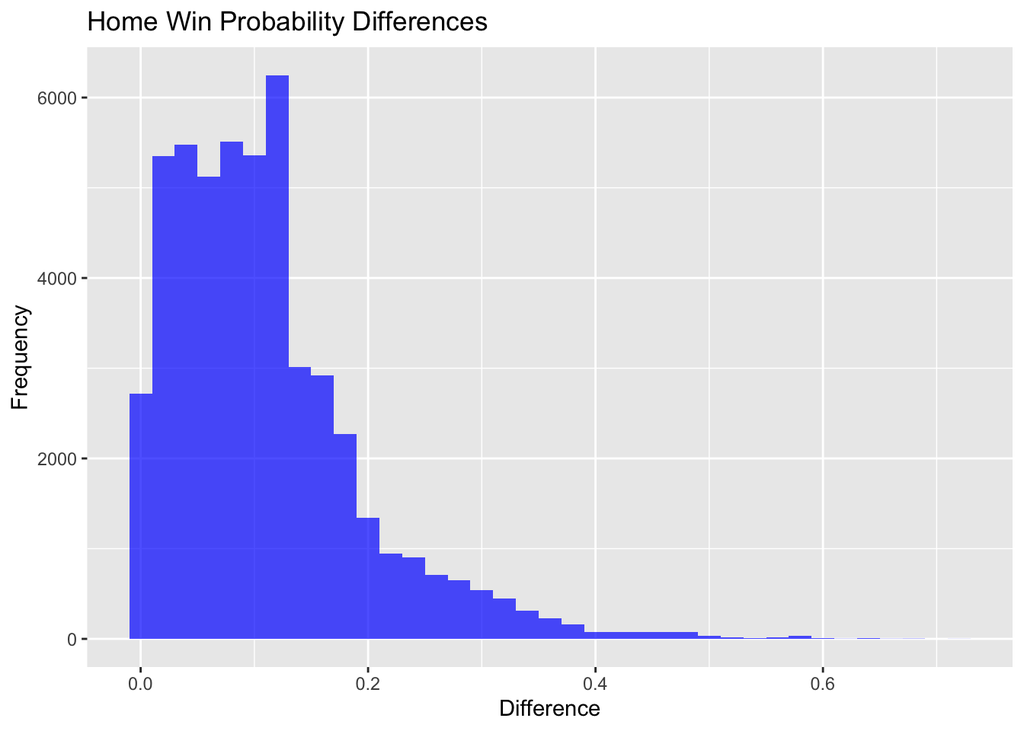

```r
library(ggplot2)

# Home Win Difference
ggplot(prepared_data, aes(x = Diff_Home_Win)) +
  geom_histogram(binwidth = 0.02, fill = "blue", alpha = 0.7) +
  labs(title = "Home Win Probability Differences", x = "Difference", y = "Frequency")
```

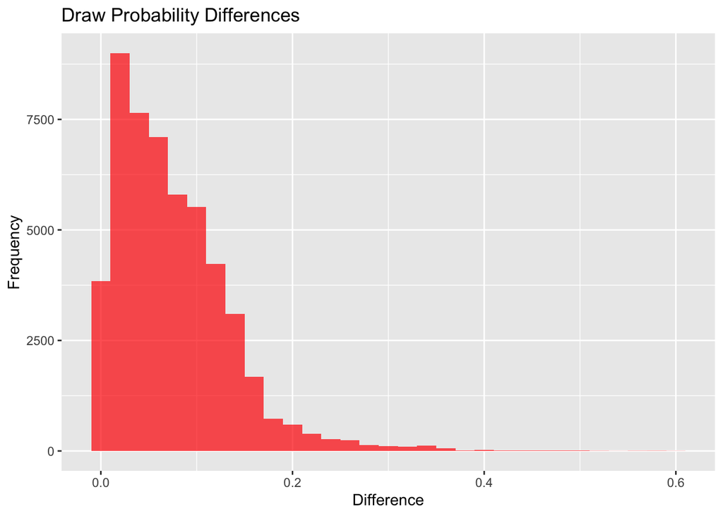

```r
# Draw Difference
ggplot(prepared_data, aes(x = Diff_Draw)) +
  geom_histogram(binwidth = 0.02, fill = "red", alpha = 0.7) +
  labs(title = "Draw Probability Differences", x = "Difference", y = "Frequency")
```

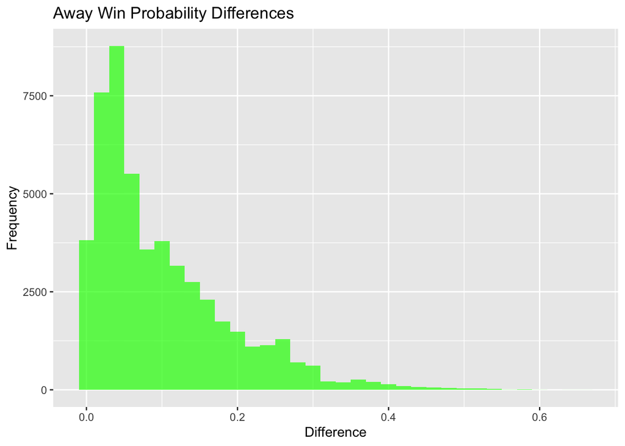

```r
# Away Win Difference
ggplot(prepared_data, aes(x = Diff_Away_Win)) +
  geom_histogram(binwidth = 0.02, fill = "green", alpha = 0.7) +
  labs(title = "Away Win Probability Differences", x = "Difference", y = "Frequency")
```